# IS-804 Project Report - Energy Efficient Data

## Introduction

The report intends to present all the statistical learning concepts introduced in the text book. The report is presented for a dataset named ‘Energy Efficient’. This dataset is collected from UCI website. There are two predicting parameter in the dataset i.e. Heating and cooling load while there are 8 predictor variables. This report will present regression technique to predict the output variables. The data can be found in following link. https://archive.ics.uci.edu/ml/datasets/Energy+efficiency

FIrst load dataset

## Chapter 2

#### Loading Data

```r
library(readxl)
energy <- read_excel("F:/Spring 2018/quantitative methods/Project/Data/energy.xlsx")
#View(energy)
#fix(energy)
dim(energy)
```

```
## [1] 768  10
```

```r
names(energy)
```

```
##  [1] "relative_compactness"      "surface_area"
##  [3] "wall_area"                 "roof_area"
##  [5] "overall_height"            "orientation"
##  [7] "glazing_area"              "glazing_area_distribution"
##  [9] "heating_load"              "cooling_load"
```

```r
summary(energy)
```

```
##  relative_compactness  surface_area     wall_area       roof_area
##  Min.   :0.6200       Min.   :514.5   Min.   :245.0   Min.   :110.2
##  1st Qu.:0.6825       1st Qu.:606.4   1st Qu.:294.0   1st Qu.:140.9
##  Median :0.7500       Median :673.8   Median :318.5   Median :183.8
##  Mean   :0.7642       Mean   :671.7   Mean   :318.5   Mean   :176.6
##  3rd Qu.:0.8300       3rd Qu.:741.1   3rd Qu.:343.0   3rd Qu.:220.5
##  Max.   :0.9800       Max.   :808.5   Max.   :416.5   Max.   :220.5
##  overall_height  orientation    glazing_area    glazing_area_distribution
##  Min.   :3.50   Min.   :2.00   Min.   :0.0000   Min.   :0.000
##  1st Qu.:3.50   1st Qu.:2.75   1st Qu.:0.1000   1st Qu.:1.750
##  Median :5.25   Median :3.50   Median :0.2500   Median :3.000
##  Mean   :5.25   Mean   :3.50   Mean   :0.2344   Mean   :2.812
##  3rd Qu.:7.00   3rd Qu.:4.25   3rd Qu.:0.4000   3rd Qu.:4.000
##  Max.   :7.00   Max.   :5.00   Max.   :0.4000   Max.   :5.000
##   heating_load    cooling_load
##  Min.   : 6.01   Min.   :10.90
##  1st Qu.:12.99   1st Qu.:15.62
##  Median :18.95   Median :22.08
##  Mean   :22.31   Mean   :24.59
##  3rd Qu.:31.67   3rd Qu.:33.13
##  Max.   :43.10   Max.   :48.03
```

```r
attach(energy)
```

#### Additional Graphical and Numerical Summaries

Following figures shows how the output variables changes with respect to different input variables.

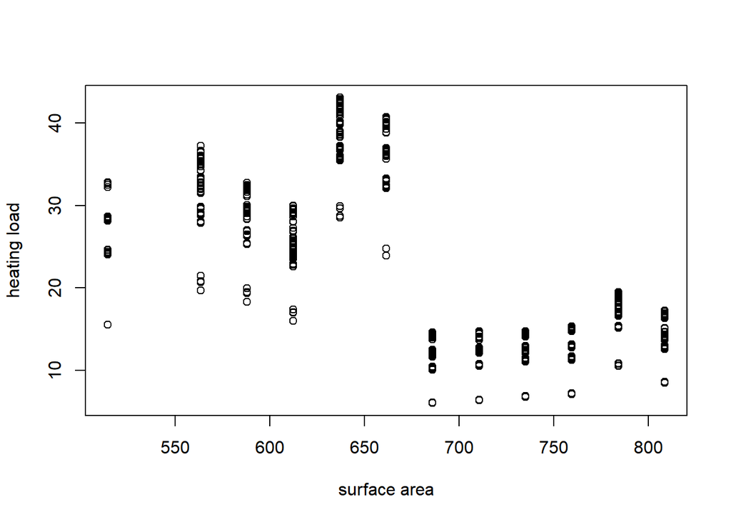

```r
plot(surface_area, heating_load,xlab='surface area', ylab='heating load')
```

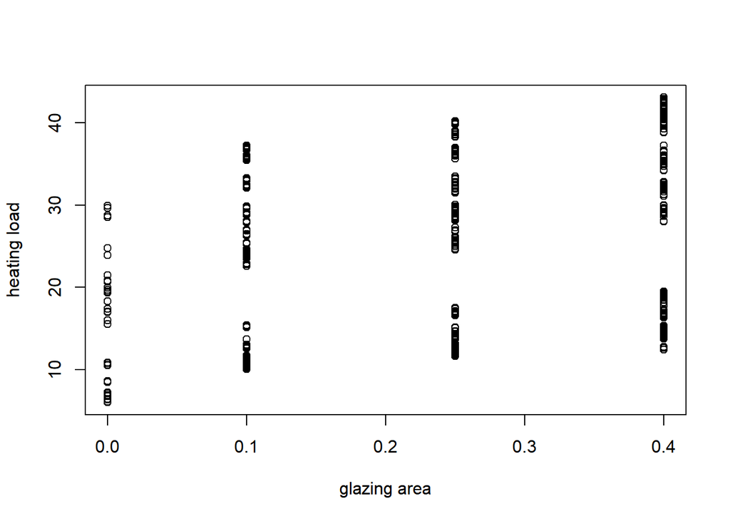

```r
plot(glazing_area, heating_load,xlab='glazing area', ylab='heating load')
```

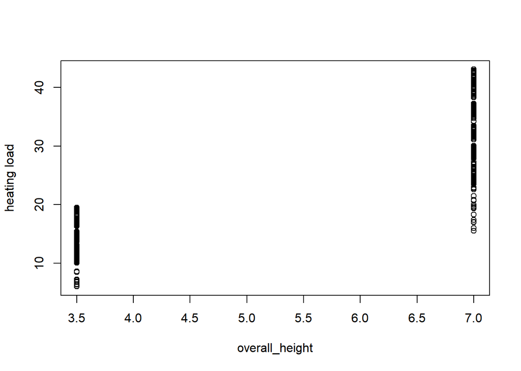

```r
plot(overall_height, heating_load,xlab='overall_height', ylab='heating load')
```

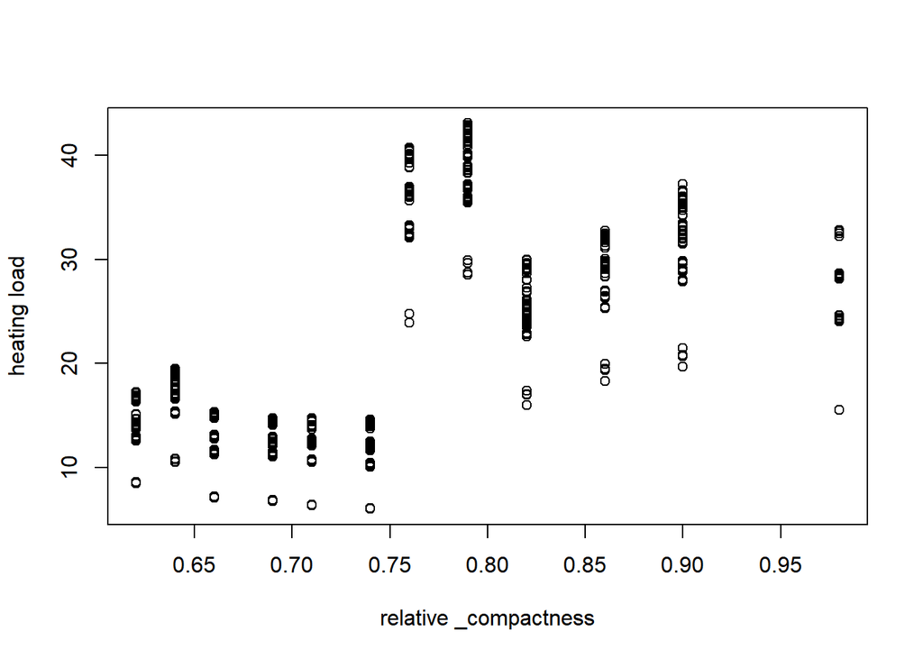

```r
plot(relative_compactness, heating_load, xlab='relative _compactness', ylab='heating load')
```

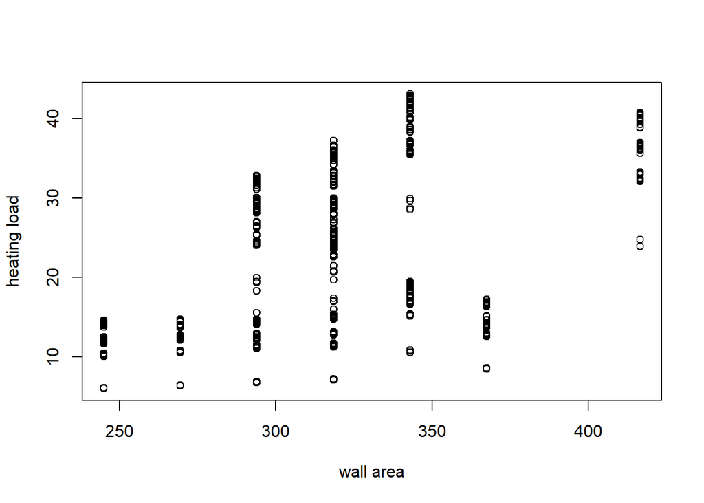

```r
plot(wall_area, heating_load,xlab='wall area', ylab='heating load')
```

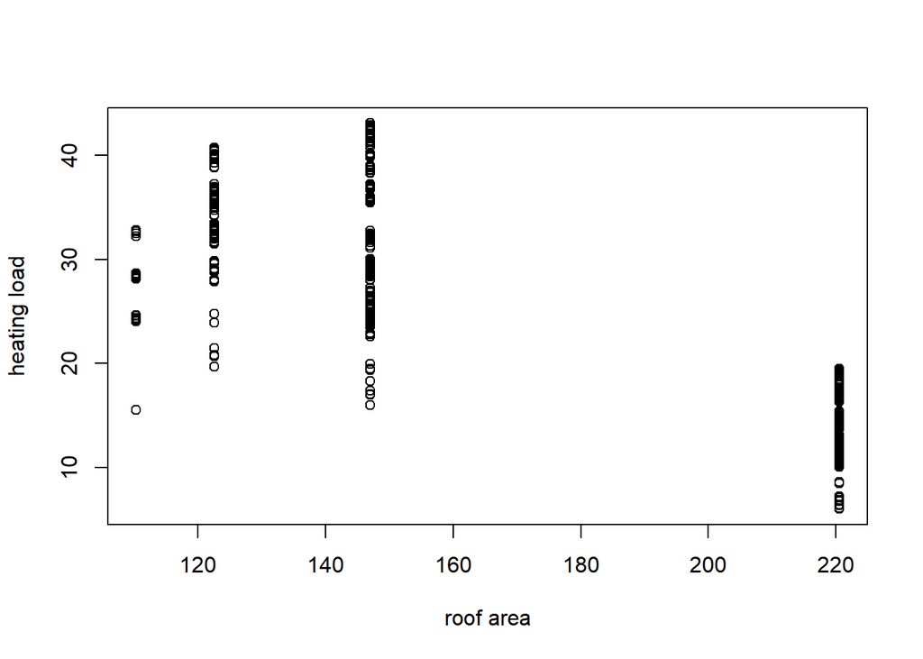

```r
plot(roof_area, heating_load,xlab='roof area', ylab='heating load')
```